# Scholastic - Customer Retention Strategy

### Importing Libraries and Reading Data:

```python
import pandas as pd
import numpy as np
import seaborn as sns
import missingno as msno
import matplotlib.pyplot as plt
import scipy.stats as stats

from datetime import datetime
from sklearn.impute import SimpleImputer
from sklearn.compose import ColumnTransformer
from sklearn.pipeline import Pipeline
from ydata_profiling import ProfileReport

from sklearn.model_selection import train_test_split, cross_val_score
from sklearn.preprocessing import LabelEncoder, StandardScaler, OneHotEncoder
from feature_engine.encoding import OneHotEncoder
from feature_engine.imputation import CategoricalImputer
from sklearn.linear_model import LogisticRegression
from sklearn.tree import DecisionTreeClassifier
from sklearn.metrics import confusion_matrix, roc_curve, roc_auc_score, auc
from sklearn.metrics import accuracy_score, precision_score, recall_score, f1_score
from sklearn.compose import ColumnTransformer
```

```python
retentiondata = pd.read_csv("D:/SIBMB/SEM 3/ML/Scholastic Case/scholastic_ret.csv")
retentiondata.sample(n=10)
```

|  | ID | Program.Code | From.Grade | To.Grade | Group.State | Is.Non.Annual. | Days | Travel.Type | Departure.Date | Return.Date | ... | GroupGradeTypeLow | GroupGradeTypeHigh | GroupGradeType | MajorProgramCode | SingleGradeTripFlag | FPP.to.School.enrollment | FPP.to.PAX | Num.of.Non_FPP.PAX | SchoolSizeIndicator | Retained.in.2012. |
| --- | --- | --- | --- | --- | --- | --- | --- | --- | --- | --- | --- | --- | --- | --- | --- | --- | --- | --- | --- | --- | --- |
| 1213 | 1214 | CVP | 8.0 | 8.0 | TN | 0 | 3 | B | 5/18/2011 | 5/22/2011 | ... | PK | High | PK->High | C | 1 | 0.190000 | 0.974359 | 1 | S | 0 |
| 1492 | 1493 | HD | 8.0 | 8.0 | MI | 0 | 3 | B | 6/1/2011 | 6/3/2011 | ... | Elementary | Middle | Elementary->Middle | H | 1 | 0.148148 | 0.900000 | 8 | S-M | 1 |
| 980 | 981 | HD | 5.0 | 5.0 | CA | 0 | 5 | A | 5/1/2011 | 5/5/2011 | ... | PK | Middle | PK->Middle | H | 1 | 0.164286 | 0.920000 | 4 | S | 1 |
| 1390 | 1391 | SC | 9.0 | 12.0 | CA | 0 | 7 | A | 5/29/2011 | 6/4/2011 | ... | Undefined | Undefined | Undefined->Undefined | S | 0 | 0.094340 | 0.833333 | 2 | S | 1 |
| 601 | 602 | HD | 8.0 | 8.0 | CA | 0 | 5 | A | 4/9/2011 | 4/13/2011 | ... | Middle | Middle | Middle->Middle | H | 1 | 0.089000 | 0.890000 | 11 | L | 1 |
| 1055 | 1056 | HD | 6.0 | 8.0 | MN | 0 | 4 | A | 5/5/2011 | 5/8/2011 | ... | Middle | Middle | Middle->Middle | H | 0 | 0.012665 | 0.925926 | 2 | L | 1 |
| 1361 | 1362 | HN | 10.0 | 12.0 | ID | 0 | 4 | A | 5/28/2011 | 5/31/2011 | ... | High | High | High->High | H | 0 | 0.009212 | 0.900000 | 1 | L | 0 |
| 30 | 31 | HD | 8.0 | 8.0 | MI | 0 | 5 | B | 2/18/2011 | 2/22/2011 | ... | Middle | Middle | Middle->Middle | H | 1 | 0.076159 | 0.920000 | 4 | M-L | 1 |
| 1510 | 1511 | HD | 6.0 | 8.0 | IL | 0 | 4 | A | 6/1/2011 | 6/4/2011 | ... | Middle | Middle | Middle->Middle | H | 0 | 0.020952 | 0.916667 | 1 | S-M | 0 |
| 2190 | 2191 | HD | 8.0 | 8.0 | WA | 0 | 5 | A | 6/18/2011 | 6/22/2011 | ... | Middle | Middle | Middle->Middle | H | 1 | 0.009901 | 0.833333 | 1 | S-M | 1 |

10 rows × 56 columns

```python
print(retentiondata.shape)
```

```
(2389, 56)
```

### Checking & Handling the Null Values

```python
print(retentiondata.info())
```

```
<class 'pandas.core.frame.DataFrame'>
RangeIndex: 2389 entries, 0 to 2388
Data columns (total 56 columns):
 #   Column                          Non-Null Count  Dtype
---  ------                          --------------  -----
 0   ID                              2389 non-null   int64
 1   Program.Code                    2389 non-null   object
 2   From.Grade                      2262 non-null   float64
 3   To.Grade                        2239 non-null   float64
 4   Group.State                     2389 non-null   object
 5   Is.Non.Annual.                  2389 non-null   int64
 6   Days                            2389 non-null   int64
 7   Travel.Type                     2389 non-null   object
 8   Departure.Date                  2389 non-null   object
 9   Return.Date                     2389 non-null   object
```

[output cut: 49 more lines]

```python
retentiondata.isnull().sum()
```

```
ID                                   0
Program.Code                         0
From.Grade                         127
To.Grade                           150
Group.State                          0
Is.Non.Annual.                       0
Days                                 0
Travel.Type                          0
Departure.Date                       0
Return.Date                          0
Deposit.Date                         0
Special.Pay                       1919
Tuition                              0
FRP.Active                           0
FRP.Cancelled                        0
FRP.Take.up.percent.                 0
Early.RPL                          673
Latest.RPL                          19
Cancelled.Pax                        0
Total.Discount.Pax                   0
Initial.System.Date                  8
Poverty.Code                       599
Region                               0
CRM.Segment                          4
School.Type                          0
Parent.Meeting.Flag                  0
MDR.Low.Grade                       68
MDR.High.Grade                      68
Total.School.Enrollment             91
Income.Level                        62
EZ.Pay.Take.Up.Rate                  0
School.Sponsor                       0
SPR.Product.Type                     0
SPR.New.Existing                     0
FPP                                  0
Total.Pax                            0
SPR.Group.Revenue                    0
NumberOfMeetingswithParents          0
FirstMeeting                       337
LastMeeting                        337
DifferenceTraveltoFirstMeeting     337
DifferenceTraveltoLastMeeting      337
SchoolGradeTypeLow                   0
SchoolGradeTypeHigh                  0
SchoolGradeType                      0
DepartureMonth                       0
GroupGradeTypeLow                    0
GroupGradeTypeHigh                   0
GroupGradeType                       0
MajorProgramCode                     0
SingleGradeTripFlag                  0
FPP.to.School.enrollment            91
FPP.to.PAX                           0
Num.of.Non_FPP.PAX                   0
SchoolSizeIndicator                 91
Retained.in.2012.                    0
dtype: int64
```

```python
# Replacing specific representations of null values with pandas NaN
retentiondata.replace(['Null', '[]', 'NA'], pd.NA, inplace=True)
```

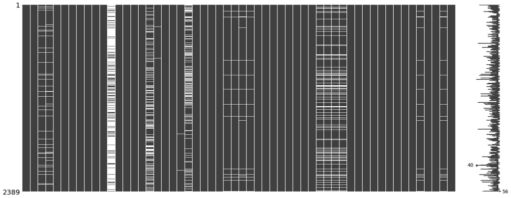

```python
# Visualizing missing values in the  dataset as a matrix
msno.matrix(retentiondata)
```

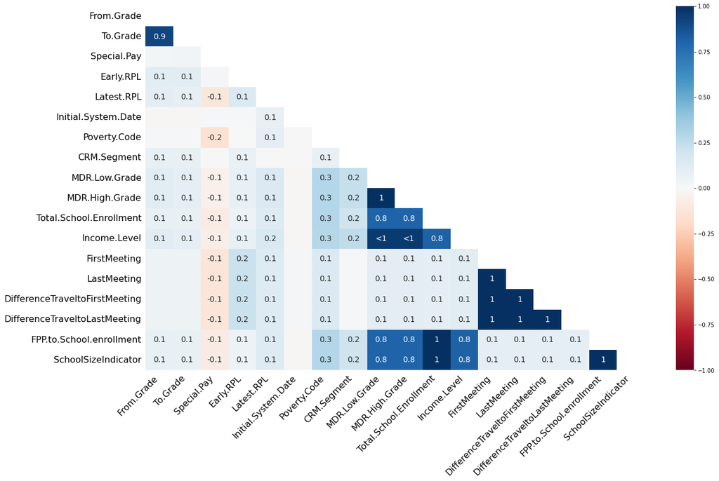

```python
# Visualizing the correlation between the number of missing values in different columns as a heatmap
msno.heatmap(retentiondata)
```

```python
retentiondata.columns = retentiondata.columns.str.replace('.', '')
print(retentiondata.info())
```

```
<class 'pandas.core.frame.DataFrame'>
RangeIndex: 2389 entries, 0 to 2388
Data columns (total 56 columns):
 #   Column                          Non-Null Count  Dtype
---  ------                          --------------  -----
 0   ID                              2389 non-null   int64
 1   ProgramCode                     2389 non-null   object
 2   FromGrade                       2262 non-null   float64
 3   ToGrade                         2239 non-null   float64
 4   GroupState                      2389 non-null   object
 5   IsNonAnnual                     2389 non-null   int64
 6   Days                            2389 non-null   int64
 7   TravelType                      2389 non-null   object
 8   DepartureDate                   2389 non-null   object
 9   ReturnDate                      2389 non-null   object
```

[output cut: 49 more lines]

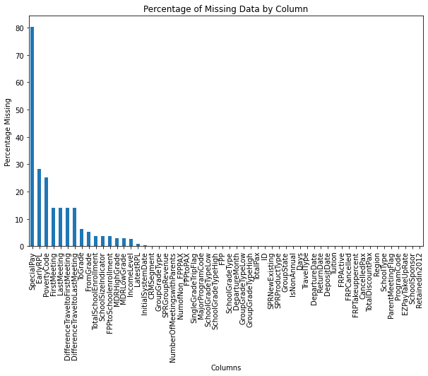

```python
missing_percentage = (retentiondata.isnull().sum() / len(retentiondata)) * 100
plt.figure(figsize=(10, 6))
missing_percentage.sort_values(ascending=False).plot(kind='bar')
plt.title('Percentage of Missing Data by Column')
plt.xlabel('Columns')
plt.ylabel('Percentage Missing')
plt.show()
```

```python
# Calculating the percentage of missing data in each column
missingvalues_percentage = (retentiondata.isnull().sum() / len(retentiondata)) * 100

# Displaying the DataFrame sorted by missing percentage in descending order
missingvalues_percentage = missingvalues_percentage.sort_values(ascending=False).head(16)
print(missingvalues_percentage)
```

```
SpecialPay                        80.326496
EarlyRPL                          28.170783
PovertyCode                       25.073252
FirstMeeting                      14.106321
LastMeeting                       14.106321
DifferenceTraveltoFirstMeeting    14.106321
DifferenceTraveltoLastMeeting     14.106321
ToGrade                            6.278778
FromGrade                          5.316032
TotalSchoolEnrollment              3.809125
SchoolSizeIndicator                3.809125
FPPtoSchoolenrollment              3.809125
MDRHighGrade                       2.846379
MDRLowGrade                        2.846379
IncomeLevel                        2.595228
LatestRPL                          0.795312
dtype: float64
```

1. Here, We can clearly see that the column SpecialPay has almost 80% of missing data so not much useful information could be derived from this column. Hence, we are going to drop this column
2. Plus, We are dropping these columns ('ID','EarlyRPL', 'LatestRPL') too as they seem irrelevant to our case.

```python
retentiondata.drop(columns=['SpecialPay','ID','EarlyRPL', 'LatestRPL'], inplace=True)
retentiondata.head(n=10)
```

|  | ProgramCode | FromGrade | ToGrade | GroupState | IsNonAnnual | Days | TravelType | DepartureDate | ReturnDate | DepositDate | ... | GroupGradeTypeLow | GroupGradeTypeHigh | GroupGradeType | MajorProgramCode | SingleGradeTripFlag | FPPtoSchoolenrollment | FPPtoPAX | NumofNon_FPPPAX | SchoolSizeIndicator | Retainedin2012 |
| --- | --- | --- | --- | --- | --- | --- | --- | --- | --- | --- | --- | --- | --- | --- | --- | --- | --- | --- | --- | --- | --- |
| 0 | HS | 4.0 | 4.0 | CA | 0 | 1 | A | 1/14/2011 | 1/14/2011 | 8/30/2010 | ... | K | Elementary | K->Elementary | H | 1 | 0.063646 | 0.936508 | 4 | L | 1 |
| 1 | HC | 8.0 | 8.0 | AZ | 0 | 7 | A | 1/14/2011 | 1/21/2011 | 11/15/2009 | ... | Middle | Middle | Middle->Middle | H | 1 | 0.025882 | 0.880000 | 3 | L | 1 |
| 2 | HD | 8.0 | 8.0 | FL | 0 | 3 | A | 1/15/2011 | 1/17/2011 | 10/15/2010 | ... | Middle | Middle | Middle->Middle | H | 1 | 0.025131 | 0.888889 | 3 | L | 1 |
| 3 | HN | 9.0 | 12.0 | VA | 1 | 3 | B | 1/15/2011 | 1/17/2011 | 1/7/2011 | ... | Undefined | Undefined | Undefined->Undefined | H | 0 | NaN | 1.000000 | 0 | NaN | 0 |
| 4 | HD | 6.0 | 8.0 | FL | 0 | 6 | T | 1/16/2011 | 1/21/2011 | 9/30/2010 | ... | Middle | Middle | Middle->Middle | H | 0 | 0.112500 | 0.910112 | 8 | M-L | 0 |
| 5 | HC | 10.0 | 12.0 | LA | 0 | 4 | A | 1/17/2011 | 1/20/2011 | 9/30/2010 | ... | High | High | High->High | H | 0 | 0.010650 | 0.909091 | 1 | L | 1 |
| 6 | SG | 11.0 | 12.0 | MA | 1 | 6 | A | 1/18/2011 | 1/23/2011 | 10/15/2010 | ... | High | High | High->High | S | 0 | 0.111111 | 0.925926 | 2 | S | 0 |
| 7 | FN | 9.0 | 9.0 | MX | 0 | 8 | A | 1/24/2011 | 1/31/2011 | 10/1/2010 | ... | Undefined | Undefined | Undefined->Undefined | I | 1 | NaN | 0.928571 | 1 | NaN | 0 |
| 8 | CC | 8.0 | 8.0 | AZ | 0 | 8 | A | 1/29/2011 | 2/5/2011 | 6/1/2010 | ... | Middle | High | Middle->High | C | 1 | 0.104000 | 0.928571 | 4 | S-M | 1 |
| 9 | HD | 8.0 | 8.0 | TX | 0 | 4 | A | 2/7/2011 | 2/10/2011 | 10/25/2010 | ... | PK | Middle | PK->Middle | H | 1 | 0.103937 | 0.916667 | 6 | M-L | 1 |

10 rows × 52 columns

### Handling Missing values

```python
retentiondata['PovertyCode'] = retentiondata['PovertyCode'].fillna('Unknown')
retentiondata['IncomeLevel'] = retentiondata['IncomeLevel'].fillna('Unknown')
```

```python
# Dropping rows containing any null values
retentiondata.dropna(inplace=True)
```

```python
# Calculating the age range for each trip
retentiondata['AgeRange'] = retentiondata['ToGrade'] - retentiondata['FromGrade']
print(retentiondata.info())
```

```
<class 'pandas.core.frame.DataFrame'>
Int64Index: 1866 entries, 0 to 2388
Data columns (total 53 columns):
 #   Column                          Non-Null Count  Dtype
---  ------                          --------------  -----
 0   ProgramCode                     1866 non-null   object
 1   FromGrade                       1866 non-null   float64
 2   ToGrade                         1866 non-null   float64
 3   GroupState                      1866 non-null   object
 4   IsNonAnnual                     1866 non-null   int64
 5   Days                            1866 non-null   int64
 6   TravelType                      1866 non-null   object
 7   DepartureDate                   1866 non-null   object
 8   ReturnDate                      1866 non-null   object
 9   DepositDate                     1866 non-null   object
```

[output cut: 46 more lines]

```python
retentiondata.sample(n=10)
```

|  | ProgramCode | FromGrade | ToGrade | GroupState | IsNonAnnual | Days | TravelType | DepartureDate | ReturnDate | DepositDate | ... | GroupGradeTypeHigh | GroupGradeType | MajorProgramCode | SingleGradeTripFlag | FPPtoSchoolenrollment | FPPtoPAX | NumofNon_FPPPAX | SchoolSizeIndicator | Retainedin2012 | AgeRange |
| --- | --- | --- | --- | --- | --- | --- | --- | --- | --- | --- | --- | --- | --- | --- | --- | --- | --- | --- | --- | --- | --- |
| 290 | SK | 8.0 | 8.0 | IL | 0 | 5 | A | 3/21/2011 | 3/25/2011 | 11/15/2010 | ... | Middle | Middle->Middle | S | 1 | 0.014286 | 0.937500 | 1 | L | 1 | 0.0 |
| 268 | HD | 8.0 | 8.0 | IL | 0 | 3 | A | 3/20/2011 | 3/22/2011 | 10/1/2010 | ... | Middle | Middle->Middle | H | 1 | 0.111579 | 0.905983 | 11 | L | 1 | 0.0 |
| 365 | SK | 9.0 | 12.0 | WA | 1 | 5 | A | 3/26/2011 | 3/30/2011 | 11/19/2010 | ... | High | High->High | S | 0 | 0.002939 | 0.800000 | 1 | L | 0 | 3.0 |
| 1905 | HN | 7.0 | 8.0 | TX | 0 | 4 | A | 6/9/2011 | 6/12/2011 | 10/15/2010 | ... | Middle | Middle->Middle | H | 0 | 0.048571 | 0.944444 | 1 | S-M | 0 | 1.0 |
| 740 | HC | 7.0 | 8.0 | CA | 1 | 7 | A | 4/16/2011 | 4/23/2011 | 10/31/2010 | ... | Middle | Middle->Middle | H | 0 | 0.064715 | 0.933333 | 3 | M-L | 0 | 1.0 |
| 1316 | HD | 8.0 | 8.0 | OH | 0 | 4 | A | 5/25/2011 | 5/29/2011 | 10/8/2010 | ... | Middle | Middle->Middle | H | 1 | 0.132376 | 0.902174 | 9 | M-L | 1 | 0.0 |
| 931 | HC | 8.0 | 8.0 | CA | 0 | 5 | A | 4/26/2011 | 4/30/2011 | 10/22/2010 | ... | Middle | PK->Middle | H | 1 | 0.049180 | 0.900000 | 1 | S | 1 | 0.0 |
| 1750 | HD | 8.0 | 8.0 | TX | 0 | 4 | A | 6/7/2011 | 6/10/2011 | 10/29/2010 | ... | Middle | Middle->Middle | H | 1 | 0.006542 | 0.875000 | 1 | L | 1 | 0.0 |
| 382 | HD | 8.0 | 8.0 | CA | 0 | 5 | A | 3/27/2011 | 3/31/2011 | 11/1/2010 | ... | Middle | K->Middle | H | 1 | 0.065957 | 0.939394 | 2 | S-M | 1 | 0.0 |
| 753 | ST | 7.0 | 11.0 | NJ | 1 | 5 | A | 4/17/2011 | 4/21/2011 | 10/31/2010 | ... | Middle | Middle->Middle | S | 0 | 0.007273 | 0.666667 | 2 | S-M | 0 | 4.0 |

10 rows × 53 columns

## Exploratory Data Analysis

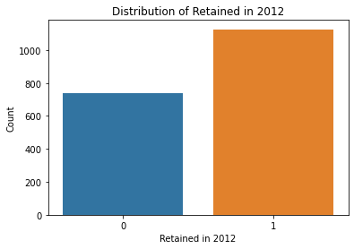

```python
# Distribution analysis the our Target Variable
sns.countplot(x='Retainedin2012', data=retentiondata)
plt.title('Distribution of Retained in 2012')
plt.xlabel('Retained in 2012')
plt.ylabel('Count')
plt.show()
```

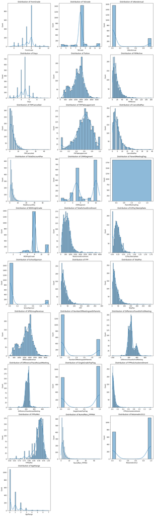

```python
# Doing a Distribution analysis of the columns
num_columns = retentiondata.select_dtypes(include=['float64', 'int64']).columns
num_cols_per_row = 3  # Number of numerical columns per row
num_rows = (len(num_columns) - 1) // num_cols_per_row + 1

# Creating a grid of distribution plots
plt.figure(figsize=(15, 5 * num_rows))
for i, col in enumerate(num_columns, start=1):
    plt.subplot(num_rows, num_cols_per_row, i)
    sns.histplot(retentiondata[col], kde=True)
    plt.title(f'Distribution of {col}')
    plt.tight_layout()

plt.show()
```

**FromGrade and ToGrade:**

**IsNonAnnual:**

- The distribution shows that most programs are not non-annual (0), with fewer being non-annual (1).

**Days:**

- The majority of programs involve a lower number of days.

**Tuition:**

**FRPActive and FRPCancelled:**

**CancelledPax and TotalDiscountPax:**

- Both columns are right-skewed, indicating that most programs have fewer canceled passengers or discounted passengers.
- A smaller number of programs have a higher count of canceled or discounted passengers.

**TotalSchoolEnrollment:**

- Most schools have a moderate enrollment, with fewer schools having extremely high enrollments.

**EZPayTakeUpRate:**

- Participants have varying rates of signing up for the automatic bank draft installment plan.

**SPRGroupRevenue:**

- Most programs have relatively lower group revenues, with a few having higher revenues.

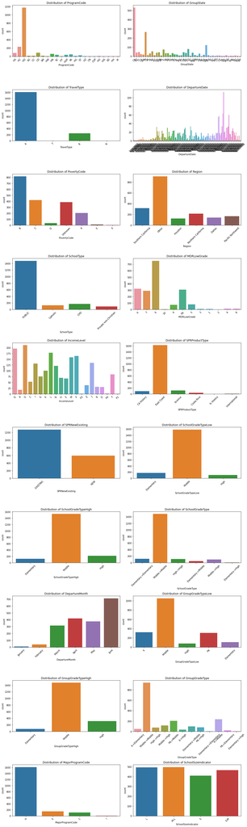

```python
# Excluding non-date columns
exclude_columns = ['ReturnDate', 'DepositDate', 'EarlyRPL', 'LatestRPL', 'InitialSystemDate', 'FirstMeeting', 'LastMeeting']
categorical_columns = retentiondata.select_dtypes(include=['object']).columns
cat_columns = [col for col in categorical_columns if col not in exclude_columns]
num_cols_per_row = 2  # Number of categorical columns per row
num_rows = (len(cat_columns) - 1) // num_cols_per_row + 1

# Create a grid of count plots
plt.figure(figsize=(15, 5 * num_rows))
for i, col in enumerate(cat_columns, start=1):
    plt.subplot(num_rows, num_cols_per_row, i)
    sns.countplot(data=retentiondata, x=col)
    plt.title(f'Distribution of {col}')
    plt.xticks(rotation=45)
    plt.tight_layout()

plt.show()
```

**Group State Distribution:**

**Travel Type Distribution:**

- Air ('A') is the most common mode of travel for the groups.

**Poverty Code Distribution:**

**Region Distribution:**

**School Type Distribution:**

- Public schools are more prevalent in the dataset compared to private schools.

**School Sponsor Distribution:**

- The majority of groups are not officially sponsored by schools.

**SPR New Existing Distribution:**

- Groups with existing travel history ('EXISTING') are more common than those new to travel ('NEW').

**School Grade Type Low Distribution:**

- The distribution of low-grade types in schools varies across the dataset.

**Departure Month Distribution:**

- June is more prevalent month of travel for the trips

**Tuition**:

- While most participants pay a common tuition fee, some opt for more expensive packages.

**FRPActive**:

- Most participants either opt for or do not opt for FRP, with only a few outliers showing different behavior.

**FRPCancelled**:

- Most participants who purchased FRP did not cancel it. The distribution is skewed towards 0, indicating that only a small number of participants who bought FRP actually canceled it.

**CancelledPax**:

- Most trips have a low number of canceled passengers. However, there are some trips with higher numbers of canceled passengers, as shown by the outliers.

**TotalDiscountPax**:

- The majority of trips have a low number of passengers who received total discounts.

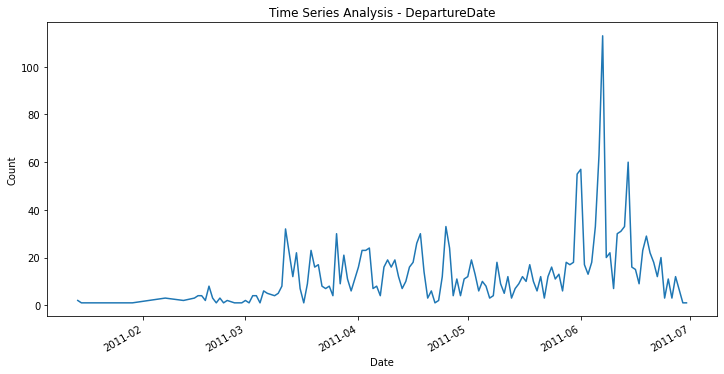

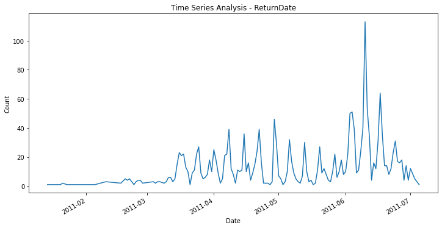

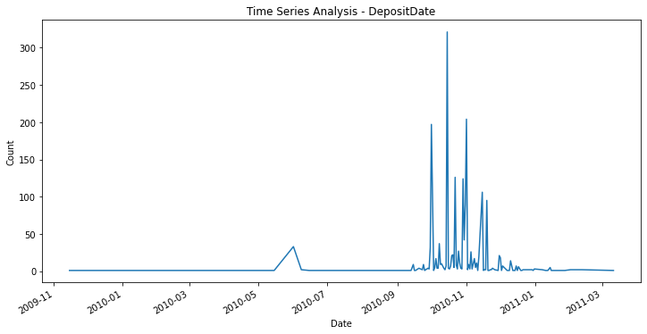

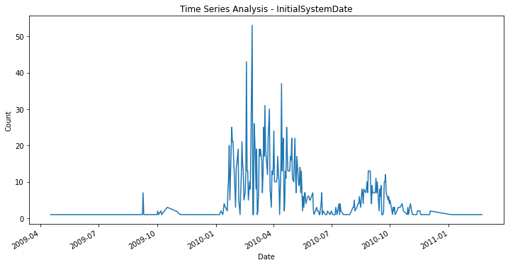

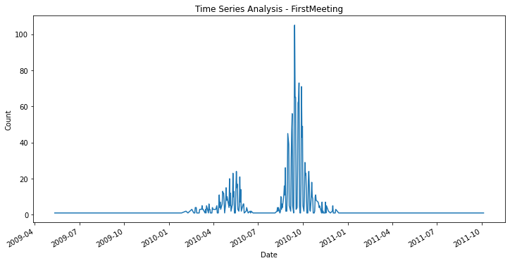

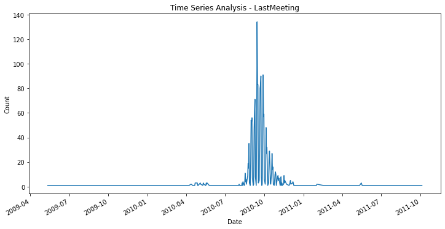

```python
# List of date-based columns
date_columns = ['DepartureDate', 'ReturnDate', 'DepositDate', 'InitialSystemDate', 'FirstMeeting', 'LastMeeting']

# Converting date columns to datetime
for col in date_columns:
    retentiondata[col] = pd.to_datetime(retentiondata[col])

# Time series analysis using line plots for each date column
for col in date_columns:
    time_series = retentiondata.groupby(col).size()
    plt.figure(figsize=(12, 6))
    time_series.plot()
    plt.title(f'Time Series Analysis - {col}')
    plt.xlabel('Date')
    plt.ylabel('Count')
    plt.show()
```

### Handling Date Features

```python
# Converting string dates to DateTime
date_columns = ['DepartureDate', 'ReturnDate', 'DepositDate', 'InitialSystemDate', 'FirstMeeting', 'LastMeeting']
retentiondata[date_columns] = retentiondata[date_columns].apply(pd.to_datetime, errors='coerce')

# 'errors' parameter set to 'coerce' will replace invalid dates with NaT (Not a Time)
```

```python
# Creating a new column indicating whether the trip is within the same month of departure
retentiondata['WithinSameMonth'] = (retentiondata['DepartureDate'].dt.month == retentiondata['ReturnDate'].dt.month).astype(int)
```

```python
# Converting dates to a specific format (e.g., 'YYYY-MM-DD')
retentiondata['DepartureDate'] = retentiondata['DepartureDate'].dt.strftime('%Y-%m-%d')
retentiondata['ReturnDate'] = retentiondata['ReturnDate'].dt.strftime('%Y-%m-%d')
retentiondata['DepositDate'] = retentiondata['DepositDate'].dt.strftime('%Y-%m-%d')
```

```python
# I Want a separate column to tell me the duration of trip
retentiondata['DepartureDate'] = pd.to_datetime(retentiondata['DepartureDate'])
retentiondata['ReturnDate'] = pd.to_datetime(retentiondata['ReturnDate'])

retentiondata['TripDuration'] = retentiondata['ReturnDate'] - retentiondata['DepartureDate']
retentiondata['TripDurationInDays'] = retentiondata['TripDuration'].dt.days
```

```python
# Dropping the additional date columns

drop_columns = ["TripDuration","DepartureDate", "ReturnDate"]
retentiondata = retentiondata.drop(columns=drop_columns)
```

### Date Format Correction

```python
retentiondata.sample(n=20)
```

|  | ProgramCode | FromGrade | ToGrade | GroupState | IsNonAnnual | Days | TravelType | DepositDate | Tuition | FRPActive | ... | MajorProgramCode | SingleGradeTripFlag | FPPtoSchoolenrollment | FPPtoPAX | NumofNon_FPPPAX | SchoolSizeIndicator | Retainedin2012 | AgeRange | WithinSameMonth | TripDurationInDays |
| --- | --- | --- | --- | --- | --- | --- | --- | --- | --- | --- | --- | --- | --- | --- | --- | --- | --- | --- | --- | --- | --- |
| 1955 | SK | 9.0 | 12.0 | MO | 0 | 5 | A | 2010-10-15 | 1932 | 3 | ... | S | 0 | 0.009589 | 0.875000 | 1 | M-L | 0 | 3.0 | 1 | 4 |
| 616 | HD | 8.0 | 8.0 | CA | 0 | 7 | A | 2010-10-31 | 2108 | 17 | ... | H | 1 | 0.036053 | 0.950000 | 2 | L | 1 | 0.0 | 1 | 6 |
| 2177 | HD | 7.0 | 8.0 | OR | 0 | 5 | A | 2010-11-01 | 1918 | 4 | ... | H | 0 | 0.036496 | 0.909091 | 2 | S-M | 0 | 1.0 | 1 | 4 |
| 1592 | HC | 7.0 | 8.0 | IA | 0 | 4 | A | 2010-11-04 | 1699 | 22 | ... | H | 0 | 0.082857 | 0.906250 | 3 | S-M | 0 | 1.0 | 1 | 3 |
| 1436 | HD | 7.0 | 8.0 | OK | 0 | 4 | A | 2010-10-01 | 1396 | 26 | ... | H | 0 | 0.032328 | 0.937500 | 2 | L | 1 | 1.0 | 0 | 3 |
| 776 | HD | 6.0 | 8.0 | MA | 0 | 3 | B | 2010-10-15 | 729 | 10 | ... | H | 0 | 0.019792 | 0.904762 | 2 | L | 1 | 2.0 | 1 | 3 |
| 2249 | HD | 6.0 | 8.0 | OR | 1 | 5 | A | 2010-10-15 | 1739 | 46 | ... | H | 0 | 0.073885 | 0.906250 | 6 | M-L | 0 | 2.0 | 1 | 4 |
| 675 | HC | 7.0 | 8.0 | CA | 0 | 6 | A | 2010-10-05 | 2099 | 8 | ... | H | 0 | 0.047761 | 0.914286 | 3 | M-L | 1 | 1.0 | 1 | 5 |
| 407 | HC | 11.0 | 12.0 | NE | 0 | 5 | A | 2010-10-31 | 2049 | 8 | ... | H | 0 | 0.147651 | 0.916667 | 2 | S | 0 | 1.0 | 0 | 4 |
| 2116 | HC | 7.0 | 8.0 | IN | 0 | 5 | A | 2010-10-01 | 1888 | 8 | ... | H | 0 | 0.037500 | 0.833333 | 3 | S-M | 0 | 1.0 | 1 | 4 |
| 97 | HW | 7.0 | 8.0 | SC | 0 | 3 | B | 2010-10-15 | 890 | 6 | ... | H | 0 | 0.023077 | 0.937500 | 1 | M-L | 0 | 1.0 | 1 | 2 |
| 795 | HC | 7.0 | 8.0 | CA | 0 | 5 | A | 2010-11-17 | 2299 | 15 | ... | H | 0 | 0.018400 | 0.884615 | 3 | L | 0 | 1.0 | 1 | 4 |
| 1239 | HS | 4.0 | 4.0 | CA | 0 | 1 | A | 2010-10-29 | 383 | 6 | ... | H | 1 | 0.026702 | 0.952381 | 1 | M-L | 1 | 0.0 | 1 | 0 |
| 36 | HD | 8.0 | 8.0 | IN | 0 | 3 | A | 2010-10-20 | 1174 | 37 | ... | H | 1 | 0.047619 | 0.938776 | 3 | L | 1 | 0.0 | 1 | 2 |
| 1725 | HC | 8.0 | 8.0 | CA | 0 | 6 | A | 2010-10-15 | 2466 | 6 | ... | H | 1 | 0.043478 | 0.928571 | 1 | S | 1 | 0.0 | 1 | 5 |
| 17 | SG | 8.0 | 8.0 | VA | 0 | 5 | A | 2010-10-15 | 1880 | 5 | ... | S | 1 | 0.019272 | 0.900000 | 1 | S-M | 1 | 0.0 | 1 | 4 |
| 1352 | HD | 8.0 | 8.0 | IL | 0 | 3 | A | 2010-10-22 | 999 | 17 | ... | H | 1 | 0.069712 | 0.906250 | 3 | S-M | 1 | 0.0 | 1 | 2 |
| 1331 | HD | 8.0 | 8.0 | CA | 0 | 5 | A | 2010-11-01 | 2093 | 31 | ... | H | 1 | 0.034813 | 0.869565 | 6 | L | 1 | 0.0 | 1 | 5 |
| 2026 | HD | 8.0 | 8.0 | TX | 0 | 4 | A | 2010-10-01 | 1718 | 3 | ... | H | 1 | 0.007246 | 0.833333 | 1 | M-L | 0 | 0.0 | 1 | 3 |
| 1702 | HC | 8.0 | 8.0 | TX | 0 | 5 | A | 2010-11-01 | 1840 | 9 | ... | H | 1 | 0.010393 | 0.900000 | 1 | L | 1 | 0.0 | 1 | 4 |

20 rows × 53 columns

```python
# Dropping unnecessary columns
columns_to_remove = [
    "FirstMeeting",
    "LastMeeting",
    "DifferenceTraveltoFirstMeeting",
    "DifferenceTraveltoLastMeeting",
    "InitialSystemDate",
]

retentiondata = retentiondata.drop(columns=columns_to_remove)

# Saving the cleaned DataFrame to a new CSV file
retentiondata.to_csv('cleaned_scholastic_data.csv', index=False)
```

```python
# Converting 'DepositDate' to datetime format
retentiondata['DepositDate'] = pd.to_datetime(retentiondata['DepositDate'], errors='coerce')

# Extract year, month, and day features
retentiondata['DepositDate_Year'] = retentiondata['DepositDate'].dt.year
retentiondata['DepositDate_Month'] = retentiondata['DepositDate'].dt.month
retentiondata['DepositDate_Day'] = retentiondata['DepositDate'].dt.day

# Dropping the original 'DepositDate' column
retentiondata.drop(columns=['DepositDate'], inplace=True)
```

```python
retentiondata.info()
```

```
<class 'pandas.core.frame.DataFrame'>
Int64Index: 1866 entries, 0 to 2388
Data columns (total 50 columns):
 #   Column                       Non-Null Count  Dtype
---  ------                       --------------  -----
 0   ProgramCode                  1866 non-null   object
 1   FromGrade                    1866 non-null   float64
 2   ToGrade                      1866 non-null   float64
 3   GroupState                   1866 non-null   object
 4   IsNonAnnual                  1866 non-null   int64
 5   Days                         1866 non-null   int64
 6   TravelType                   1866 non-null   object
 7   Tuition                      1866 non-null   int64
 8   FRPActive                    1866 non-null   int64
 9   FRPCancelled                 1866 non-null   int64
```

[output cut: 42 more lines]

## Feature Engineering

```python
# List of categorical columns
categorical_columns = ['ProgramCode', 'GroupState', 'TravelType', 'PovertyCode', 'Region', 'SchoolType',
                       'MDRLowGrade', 'IncomeLevel', 'SPRProductType', 'SPRNewExisting',
                       'SchoolGradeTypeLow', 'SchoolGradeTypeHigh', 'SchoolGradeType',
                       'DepartureMonth', 'GroupGradeTypeLow', 'GroupGradeTypeHigh', 'GroupGradeType',
                       'MajorProgramCode', 'SchoolSizeIndicator']

# One-hot encoding for categorical variables
retentiondata_encoded = pd.get_dummies(retentiondata, columns=categorical_columns, drop_first=True)

# Displaying the modified DataFrame
print(retentiondata_encoded.head())
```

```
   FromGrade  ToGrade  IsNonAnnual  Days  Tuition  FRPActive  FRPCancelled  \
0        4.0      4.0            0     1      424         25             3
1        8.0      8.0            0     7     2350          9             9
2        8.0      8.0            0     3     1181         17             6
4        6.0      8.0            0     6      865         40             8
5       10.0     12.0            0     4     2025          9             4

   FRPTakeuppercent  CancelledPax  TotalDiscountPax  ...  \
0             0.424             3                 4  ...
1             0.409            11                 3  ...
2             0.708             6                 3  ...
4             0.494             9                 8  ...
5             0.900             3                 1  ...

   GroupGradeType_Middle->Middle  GroupGradeType_PK->Elementary  \
```

[output cut: 28 more lines]

```python
retentiondata_encoded.sample(n=20)
```

|  | FromGrade | ToGrade | IsNonAnnual | Days | Tuition | FRPActive | FRPCancelled | FRPTakeuppercent | CancelledPax | TotalDiscountPax | ... | GroupGradeType_Middle->Middle | GroupGradeType_PK->Elementary | GroupGradeType_PK->High | GroupGradeType_PK->Middle | MajorProgramCode_H | MajorProgramCode_I | MajorProgramCode_S | SchoolSizeIndicator_M-L | SchoolSizeIndicator_S | SchoolSizeIndicator_S-M |
| --- | --- | --- | --- | --- | --- | --- | --- | --- | --- | --- | --- | --- | --- | --- | --- | --- | --- | --- | --- | --- | --- |
| 1775 | 6.0 | 8.0 | 0 | 4 | 1646 | 9 | 3 | 0.692 | 6 | 2 | ... | 1 | 0 | 0 | 0 | 1 | 0 | 0 | 0 | 1 | 0 |
| 1761 | 5.0 | 6.0 | 0 | 4 | 2266 | 3 | 1 | 1.000 | 1 | 1 | ... | 0 | 0 | 0 | 0 | 1 | 0 | 0 | 1 | 0 | 0 |
| 1612 | 7.0 | 9.0 | 0 | 5 | 1816 | 20 | 1 | 0.909 | 6 | 3 | ... | 1 | 0 | 0 | 0 | 1 | 0 | 0 | 1 | 0 | 0 |
| 1994 | 6.0 | 8.0 | 0 | 5 | 1981 | 11 | 1 | 0.579 | 1 | 3 | ... | 0 | 0 | 0 | 0 | 1 | 0 | 0 | 0 | 1 | 0 |
| 1591 | 6.0 | 8.0 | 0 | 4 | 1727 | 5 | 0 | 0.833 | 0 | 1 | ... | 1 | 0 | 0 | 0 | 1 | 0 | 0 | 1 | 0 | 0 |
| 507 | 5.0 | 9.0 | 0 | 6 | 2150 | 7 | 3 | 0.500 | 5 | 3 | ... | 0 | 0 | 0 | 0 | 1 | 0 | 0 | 0 | 0 | 1 |
| 2181 | 8.0 | 8.0 | 0 | 7 | 2622 | 7 | 4 | 0.368 | 3 | 1 | ... | 0 | 0 | 0 | 1 | 1 | 0 | 0 | 0 | 1 | 0 |
| 12 | 8.0 | 8.0 | 0 | 6 | 2278 | 10 | 6 | 0.455 | 6 | 1 | ... | 1 | 0 | 0 | 0 | 1 | 0 | 0 | 1 | 0 | 0 |
| 1016 | 8.0 | 8.0 | 0 | 6 | 2649 | 8 | 4 | 0.533 | 6 | 2 | ... | 0 | 0 | 0 | 1 | 0 | 0 | 0 | 0 | 1 | 0 |
| 2379 | 9.0 | 12.0 | 0 | 7 | 2299 | 3 | 2 | 0.750 | 3 | 2 | ... | 0 | 0 | 0 | 0 | 0 | 0 | 1 | 0 | 0 | 0 |
| 1264 | 8.0 | 8.0 | 0 | 4 | 1524 | 15 | 2 | 0.750 | 3 | 2 | ... | 1 | 0 | 0 | 0 | 1 | 0 | 0 | 0 | 0 | 1 |
| 832 | 3.0 | 5.0 | 1 | 1 | 419 | 7 | 2 | 0.636 | 2 | 1 | ... | 0 | 0 | 0 | 1 | 1 | 0 | 0 | 0 | 1 | 0 |
| 2345 | 7.0 | 8.0 | 0 | 5 | 1859 | 7 | 1 | 0.467 | 3 | 1 | ... | 1 | 0 | 0 | 0 | 1 | 0 | 0 | 0 | 0 | 1 |
| 1925 | 7.0 | 8.0 | 1 | 7 | 2500 | 26 | 5 | 0.813 | 8 | 3 | ... | 0 | 0 | 0 | 0 | 1 | 0 | 0 | 0 | 1 | 0 |
| 1221 | 4.0 | 4.0 | 0 | 2 | 630 | 6 | 0 | 0.667 | 2 | 1 | ... | 0 | 0 | 0 | 1 | 1 | 0 | 0 | 0 | 1 | 0 |
| 1684 | 8.0 | 8.0 | 0 | 4 | 1165 | 0 | 0 | 0.000 | 5 | 4 | ... | 0 | 0 | 0 | 0 | 1 | 0 | 0 | 0 | 0 | 1 |
| 1926 | 4.0 | 4.0 | 0 | 1 | 409 | 26 | 0 | 0.788 | 0 | 2 | ... | 0 | 0 | 0 | 0 | 1 | 0 | 0 | 1 | 0 | 0 |
| 2285 | 8.0 | 8.0 | 0 | 5 | 1999 | 17 | 8 | 0.680 | 8 | 2 | ... | 0 | 0 | 0 | 0 | 1 | 0 | 0 | 1 | 0 | 0 |
| 1788 | 8.0 | 8.0 | 0 | 4 | 1600 | 4 | 6 | 0.800 | 6 | 1 | ... | 1 | 0 | 0 | 0 | 1 | 0 | 0 | 1 | 0 | 0 |
| 1952 | 8.0 | 8.0 | 0 | 4 | 1476 | 8 | 2 | 0.533 | 3 | 2 | ... | 0 | 0 | 0 | 0 | 0 | 0 | 0 | 1 | 0 | 0 |

20 rows × 191 columns

## Data Splitting and Model Training

```python
# Separating features (X) and target (y)
X = retentiondata_encoded.drop(['Retainedin2012'], axis=1)
y = retentiondata_encoded['Retainedin2012']

# Split the data into training and testing sets
X_train, X_test, y_train, y_test = train_test_split(X, y, test_size=0.2, random_state=42)

# Initialize models
logreg_model = LogisticRegression(max_iter=10000)  # Increase max_iter if needed
cart_model = DecisionTreeClassifier()

# Train models
logreg_model.fit(X_train, y_train)
cart_model.fit(X_train, y_train)
```

```
DecisionTreeClassifier()
```

## Model Evaluation

```python
# Predictions
logreg_preds = logreg_model.predict(X_test)
cart_preds = cart_model.predict(X_test)
```

```python
# Confusion Matrix and ROC Curve for Logistic Regression
logreg_cm = confusion_matrix(y_test, logreg_preds)
fpr_logreg, tpr_logreg, thresholds_logreg = roc_curve(y_test, logreg_model.predict_proba(X_test)[:,1])
roc_auc_logreg = auc(fpr_logreg, tpr_logreg)
```

```python
# Confusion Matrix and ROC Curve for CART
cart_cm = confusion_matrix(y_test, cart_preds)
fpr_cart, tpr_cart, thresholds_cart = roc_curve(y_test, cart_model.predict_proba(X_test)[:,1])
roc_auc_cart = auc(fpr_cart, tpr_cart)
```

## Confusion Matrix Visualization

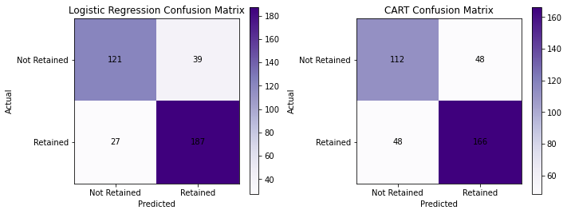

```python
# Plotting Confusion Matrices
plt.figure(figsize=(10, 4))

plt.subplot(1, 2, 1)
plt.title('Logistic Regression Confusion Matrix')
plt.imshow(logreg_cm, interpolation='nearest', cmap=plt.cm.Purples)
plt.colorbar()
plt.xticks([0, 1], ['Not Retained', 'Retained'])
plt.yticks([0, 1], ['Not Retained', 'Retained'])
plt.xlabel('Predicted')
plt.ylabel('Actual')

# Annotating Logistic Regression Confusion Matrix
for i in range(logreg_cm.shape[0]):
    for j in range(logreg_cm.shape[1]):
        plt.text(j, i, str(logreg_cm[i, j]), horizontalalignment='center', verticalalignment='center', color='black')

plt.subplot(1, 2, 2)
plt.title('CART Confusion Matrix')
plt.imshow(cart_cm, interpolation='nearest', cmap=plt.cm.Purples)
plt.colorbar()
plt.xticks([0, 1], ['Not Retained', 'Retained'])
plt.yticks([0, 1], ['Not Retained', 'Retained'])
plt.xlabel('Predicted')
plt.ylabel('Actual')

# Annotating CART Confusion Matrix
for i in range(cart_cm.shape[0]):
    for j in range(cart_cm.shape[1]):
        plt.text(j, i, str(cart_cm[i, j]), horizontalalignment='center', verticalalignment='center', color='black')

plt.tight_layout()
plt.show()
```

## Plotting ROC Curves

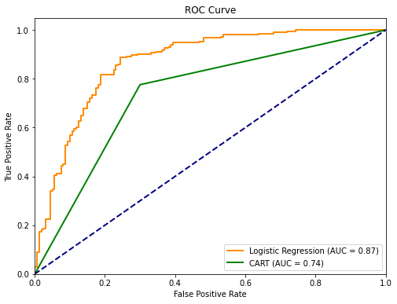

```python
plt.figure(figsize=(8, 6))
plt.plot(fpr_logreg, tpr_logreg, color='darkorange', lw=2, label='Logistic Regression (AUC = {:.2f})'.format(roc_auc_logreg))
plt.plot(fpr_cart, tpr_cart, color='green', lw=2, label='CART (AUC = {:.2f})'.format(roc_auc_cart))
plt.plot([0, 1], [0, 1], color='navy', lw=2, linestyle='--')
plt.xlim([0.0, 1.0])
plt.ylim([0.0, 1.05])
plt.xlabel('False Positive Rate')
plt.ylabel('True Positive Rate')
plt.title('ROC Curve')
plt.legend(loc='lower right')
plt.show()
```

### Interpretation of ROC Analysis and AUC:

**For Logistic Regression:**

- The Area Under the Curve (AUC) of 0.87 indicates that the Logistic Regression model has a strong ability to discriminate between "Retained" and "Not Retained" instances. The model's ROC curve is located closer to the upper left corner, demonstrating its effectiveness.

**For CART:**

- The AUC value of 0.74 suggests that the CART model's ability to distinguish between the two classes is less strong compared to Logistic Regression.

**Choosing the Ideal Probability Cutoff:**

In the context of our case study, the chosen cutoff should be based on the costs associated with false positives and false negatives. For instance, if false negatives (misclassifying retained customers as not retained) are more detrimental, the cutoff could be adjusted to reduce this type of error.

### Comparative Analysis of Logistic Regression and CART:

- Logistic Regression shows better performance with a higher AUC value (0.87), indicating its stronger discriminatory power compared to CART (AUC = 0.74).
- Logistic Regression's lower number of false positives suggests that it is more effective in correctly identifying retained customers, which aligns with the business goal of customer retention.
- Logistic Regression is the preferable choice due to its higher AUC and better performance in terms of correctly identifying retained customers.
- Logistic Regression provides a balance between identifying retained customers and minimizing false positives.